# Digital Distraction vs. Digital Tools: Investigating the Effects of Smartphone App Usage on Mood and Behavior in Young Adults

VIDEO LINK: https://drive.google.com/file/d/13wEBTBm88qJobzZwzHFR-rGIn5tQ7ze6/view?usp=sharing

# Permissions

- [ X ] YES - make available
- [ ] NO - keep private

# Names

- Rylee Boyles
- Winston Jeffries
- Liz Osborne
- Jocelyn Miao
- Jayleen Shang

# Abstract

Smartphones consume many young adults' everyday lives, serving more than just a tool for communication, but as entertainment, distraction, and emotional stimulation. Behaviors like “doom scrolling” and a heavy reliance on phones have contributed to increased screen time and changes in mental well-being. This study investigates the relationship between daily smartphone usage, measured in hours, spent on different platforms for social media, gaming, and productivity, and its potential effects on young adults aged 21-25 in the United States. Specifically, we aim to examine correlations between daily usage and variables including gender, number of users/daily time, and daily usage and emotional status. We chose to research this topic due to its relevance to young adults who often experience high levels of digital engagement, hoping to better comprehend the potential correlation between entertainment screen time, productivity and screen time’s effect on emotional well being within this subject group.

To conduct our research, we examined two separate data sets: Smartphone Usage and Behavioral Data gave us an understanding of smartphone usage patterns at the individual level, while Social Media Usage and Emotional Well-Being provided us a better grasp on user-level social media engagement and emotional state labeling. By exploring both behavioral and emotional indicators, we aimed to better understand how patterns of smartphone usage may influence productivity and mental health in this specific age group.

# Research Question

By looking at overall screen time data and its relation to daily function and emotional well-being, how does daily smartphone usage in hours spent on social media and gaming apps affect the total usage of productivity apps among young adults aged 21-25 in the US over the course of a day?

## Background and Prior Work

Smartphones are a technology that almost every young adult has in their back pocket. These devices have become intertwined with the human experience as they are a valuable tool that allows for communication, direction, and entertainment. However, these devices have become a large source of distraction, contributing to increased screen time, diminishing attention spans, and less productivity.

This trend has become something that researchers have become increasingly aware of as smartphones have integrated into young adults' lives and have started to have effects on cognition. Although there is still little research on the long term effects of smartphone usage on cognitive effects, there have been many studies looking into the immediate effects of smartphone usage on attention span.

At Temple University, the Psychology Department conducted a study on the Links between smartphones and cognitive abilities called; “Smartphones and Cognition: A Review of Research Exploring the Links between Mobile Technology Habits and Cognitive Functioning” by Henry H Wilmer, Lauren E Sherman, & Jason M Chein, where they explored effects on attention, memory, delay of gratification, and everyday cognitive functions from smartphone usage ^. These researchers highlighted concerns that frequent smartphone usage could be associated with reduced working memory, less self-control relating to delay gratification, and an overall increased reliance on these devices for cognitive functions. The study strengthens this argument by citing research previously conducted on the topic and explaining how these studies were carried out.

One of the negative impacts on attention that is highlighted in this research paper is "Frequent media multitasking"<sup>1</sup>, a behavior that is inherently tied to the nature of smartphone use. The researchers refer to this action as endogenous interruptions, where a user's thoughts drift towards smartphone-related activities, where “The ‘mere presence’ of a cell phone may produce diminished attention and worsened task-performance, especially for tasks with high cognitive demands.” <sup>2</sup> The reasoning for this is likely due to a desire for more immediate gratification once an ongoing task is no longer rewarding. Thus, these "interruptions cause up to a 4x delay in completion of a primary task "<sup>3</sup>, emphasizing how smartphones can affect productivity, focus, and the mental state of users. Additionally, "In the presence of distractor stimuli during sustained attention task, frequent media multitaskers perform worse and exhibit more right prefrontal activity" <sup>4</sup> suggesting that habitual multitasking can often facilitated by smartphone usage can be a cause for less productivity, making everyday task seem much more challenging.

The review also draws attention to how smartphone use affects both focused and sustained attention, particularly through constant interruptions. These interruptions are classified as either endogenous, which are internally driven urges to check one’s phone, or exogenous, like notifications or vibrations, which can disrupt attention even when ignored. For example, Stothart et al. found that simply hearing a phone notification, without even interacting with the device, significantly reduced performance on an attention-based task. <sup>5</sup> Similarly, the presence of a smartphone in one’s visual field has been shown to impair performance on tasks requiring higher cognitive effort. <sup>2</sup> These findings suggest that smartphones not only distract us during use but can impair cognitive functioning even when passively present. Over time, repeated interruptions may reduce our baseline ability to maintain sustained attention, making everyday tasks feel more difficult and draining. While more long term studies are needed, the existing evidence indicated a strong link between habitual smartphone engagement and a diminished capacity to focus.

These major effects on cognition are especially relevant for young adults aged 21–25, a period marked by critical transitions into independence, careers, and personal development. While smartphones offer useful tools such as navigation, communication, and organization apps, they also introduce constant opportunities for distraction. Productivity tools now compete for attention against more stimulating social media and gaming platforms. Research shows that while smartphones are often used for beneficial tasks, their constant presence can undermine focus. For instance, one study found that although a majority of users report using their smartphones for practical tasks, many also described the device as more of a distraction than a help, with noticeable shifts in behavior linked to compulsive checking habits<sup>7</sup>. Joshi et al. (2022) observed that young adults frequently engage in smartphone multitasking, a behavior tied to broader trends in digital distraction and reduced sustained attention<sup>8</sup>. Beyond attention, emotional well-being is also at stake. Exposure to negative or overwhelming content—such as during "doomscrolling," the compulsive habit of endlessly consuming distressing news or social media posts—has been linked to increases in anxiety and depressive symptoms. For many, the smartphone is no longer just a communication tool but has evolved into a constant companion, filling idle time and delivering frequent dopamine hits, often at the expense of mental health and productivity.

1. ^ Wilmer, H. H., Sherman, L. E., & Chein, J. M. (2017). Smartphones and Cognition: A Review of Research Exploring the Links between Mobile Technology Habits and Cognitive Functioning. Frontiers in psychology, 8, 605. https://doi.org/10.3389/fpsyg.2017.00605
2. ^ Thornton, B., Faires, A., Robbins, M., & Rollins, E. (2014). The mere presence of a cell phone may be distracting: Implications for attention and task performance. Social Psychology, 45(6), 479–488. https://doi.org/10.1027/1864-9335/a000216
3. ^ Leiva, L., Böhmer, M., Gehring, S., & Krüger, A. (2012). Back to the app. In Proceedings of the 14th international conference on Human-computer interaction with mobile devices and services. MobileHCI ’12: 14th International Conference on Human Computer Interaction with Mobile Devices and Services. ACM. https://doi.org/10.1145/2371574.2371617
4. ^ Moisala, M., Salmela, V., Hietajärvi, L., Salo, E., Carlson, S., Salonen, O., Lonka, K., Hakkarainen, K., Salmela-Aro, K., & Alho, K. (2016). Media multitasking is associated with distractibility and increased prefrontal activity in adolescents and young adults. NeuroImage, 134, 113–121. https://doi.org/10.1016/j.neuroimage.2016.04.011
5. ^ Stothart, C., Mitchum, A., & Yehnert, C. (2015). The attentional cost of receiving a cell phone notification. Journal of experimental psychology. Human perception and performance, 41(4), 893–897. https://doi.org/10.1037/xhp0000100
6. ^ Seilhamer, R., Chen, B., Bauer, S., Salter, A., & Bennett, L. (2018, April 23). Changing mobile learning practices: A multiyear study 2012–2016. EDUCAUSE Review. Retrieved August 1, 2021, from https://er.educause.edu/articles/2018/4/changing-mobile-learning-practices-a-multiyear-study-2012-2016#fn4
7. ^ Fernandez, S. (2018). University students’ perspectives on using cell phones in classrooms: Are they dialing up disaster? The Turkish Online Journal of Educational Technology, 17(1), 246–258.https://files.eric.ed.gov/fulltext/EJ1165729.pdf
8. ^ Joshi, S. C., Woodward, J., & Woltering, S. (2022). Cell phone use distracts young adults from academic work with limited benefit to self-regulatory behavior. Current Psychology. Advance online publication. https://doi.org/10.1007/s12144-022-03830-4

# Hypothesis

We hypothesize that young adults aged 21-25 who spend more than 4 hours per day in total on social media and gaming apps will exhibit significantly lower usage of productivity applications, along with higher average daily screen time, compared to those who limit entertainment-focused app usage to under 2 hours per day. We further expect that higher usage patterns will be associated with more frequent emotional states, particularly in categories such as anxiety, depression, and anger, as captured by the dominant emotion labels in our second dataset.

This hypothesis is grounded in the assumption that excessive engagement with entertainment apps may displace time that could be spent on cognitively beneficial or goal-oriented activities, such as using calendar tools, note-taking apps, or other productivity platforms. In turn, this substitution may contribute to reduced emotional well-being by fostering feelings of inefficiency, overstimulation, or social comparison.

# Data

## Data overview

Dataset #1: Smartphone usage and Behavior Dataset This dataset captures smartphone usage patterns at the individual level, making it highly relevant for modeling behavioral tendencies and digital well-being. Key variables include demographic descriptors (Age, Gender, and Location), quantitative metrics: (Daily_Screen_Time_Hours, Total_App_Usage_Hours, and Number_of_Apps_Used), and category specific engagement (Specific app categories: Social_Media_Usage_Hours, Productivity_App_Usage_Hours, Gaming_App_Usage_Hours). The data types are a mix of integers, floats, and categorical strings. These variables serve as proxies for attention allocation, time prioritization, and lifestyle routines. A basic inspection revealed no missing values or data-type mismatches, and summary statistics show logical ranges (e.g., screen time hours between 0 and 15). However, to adjust for our research question, we cleaned the data to reflect our focus on 21 - 25 year olds. Preprocessing steps include standardizing usage hours and constraining our age range to meet our research question. This data set is relevant to our research question as it demonstrates users' overall screen time in hours, additionally breaking down the amount of hours spent on specific apps like social media apps, gaming apps, and productivity apps. Thus allowing us to get an understanding of young adults' screen time distribution and to understand if social media/ gaming apps are really taking away time from productivity apps. When it came to missing values in this data set, we chose to get rid of incomplete data only if its incompleteness seemed purely random; otherwise, we used a strategy of complete-case analysis where if our group was faced with incomplete data, we would delete a row of data missing one of its entries. To avoid introducing a bias, we ensured that the missing data did not follow any systematic pattern. This data did not have missing values. The only changes made were to sort out the entries within our specified age group (21-25) and convert the original ‘Age’ column values from strings to integers.

Dataset #2: Social Media and Emotional Well-Being The dataset represents a complete profile of user level social media engagement and emotional state labeling, supporting our modeling goals. Key variables include platform specific behavior (Platform, Posts_Per_Day, Likes_Received_Per_Day, Comments_Received_Per_Day, Messages_Sent_Per_Day), and emotional responses (Dominant_Emotion). Most features are numerical, with some categorical fields like Gender, Platform, and Dominant_Emotion. These datasets act as proxies for emotional engagement, platform-specific intensity, and digital social interaction. A preliminary EDA across splits shows consistency, suggesting high quality. Inspecting the data, we adjusted the ages to reflect our focused group of only 21-25 year olds, and for consistency, we adjusted the data in the Daily usage time from minutes to hours, which is the metric we are using to measure screen time. Overall, this data set supports our research as it gives deeper insight into how these apps are affecting young adults' mental states and their emotional reactions to the amount of time spent on social/gaming apps. When it came to missing values in this data set, we chose to eliminate incomplete data only if its incompleteness seemed purely random; otherwise, we used a strategy of complete-case analysis where if our group was faced with incomplete data, we would delete a row of data is missing one of its entries. To avoid introducing a bias, we ensured that the missing data did not follow any systematic pattern. This data did not have missing data.

To create a comprehensive behavioral model, we will analyze both the smartphone usage data and the social media data separately, as each data set represents a distinct group of individuals. However, we plan to use these datasets to complement one another and to gain a deeper understanding and analysis when it comes to answering our overall research question. In doing so we will take into account the differences and similarities between the data and explore how the data can support each other. This approach would allow for the integration of general behavioral data with platform-specific social media engagement metrics, enabling richer models for predicting outcomes like dominant emotion or app category preference. Minor column renaming and normalization will be required to unify the merged dataset. When it comes to our overall question, using both data sets together helps us to understand how smartphone usage may disrupt daily productivity and increase engagement with social and gaming apps. Furthermore, the Social Media and Wellbeing dataset helps to reveal how social media apps also have an effect on our dominant emotions that can negatively impact one's mental well being. Together, these datasets provide a more holistic view of then relations between digital habits, productivity, and emotional health.

## Dataset #1: Smartphone Usage and Behavioral Dataset

```python
import pandas as pd
import seaborn as sns
import matplotlib.pyplot as plt
import numpy as np
from matplotlib.cm import ScalarMappable
from matplotlib.colors import Normalize
from matplotlib import colormaps
```

```python
smartphone_df = pd.read_csv("data/smartphone_usage.csv")
smartphone_df['Age'] = pd.to_numeric(smartphone_df['Age'], errors='coerce')
smartphone_filtered = smartphone_df[(smartphone_df['Age'] >= 21) & (smartphone_df['Age'] <= 25)] ## age limit

print(smartphone_filtered.describe())
smartphone_filtered.head(5)
```

```
           User_ID         Age  Total_App_Usage_Hours  \
count   117.000000  117.000000             117.000000
mean    529.264957   22.982906               6.458803
std     304.074157    1.426250               3.155530
min       4.000000   21.000000               1.020000
25%     259.000000   22.000000               3.890000
50%     563.000000   23.000000               6.660000
75%     802.000000   24.000000               9.300000
max    1000.000000   25.000000              11.800000

       Daily_Screen_Time_Hours  Number_of_Apps_Used  Social_Media_Usage_Hours  \
count               117.000000           117.000000                117.000000
mean                  8.050342            15.717949                  2.507863
std                   3.690396             7.629171                  1.551238
min                   1.030000             3.000000                  0.030000
25%                   6.090000            10.000000                  1.130000
50%                   8.140000            15.000000                  2.420000
75%                  11.240000            22.000000                  3.930000
max                  13.770000            29.000000                  4.950000

       Productivity_App_Usage_Hours  Gaming_App_Usage_Hours
count                    117.000000              117.000000
mean                       2.482650                2.420427
std                        1.405886                1.532646
min                        0.000000                0.020000
25%                        1.410000                1.130000
50%                        2.460000                2.330000
75%                        3.790000                3.960000
max                        4.980000                4.950000
```

|  | User_ID | Age | Gender | Total_App_Usage_Hours | Daily_Screen_Time_Hours | Number_of_Apps_Used | Social_Media_Usage_Hours | Productivity_App_Usage_Hours | Gaming_App_Usage_Hours | Location |
| --- | --- | --- | --- | --- | --- | --- | --- | --- | --- | --- |
| 3 | 4 | 25 | Female | 1.20 | 6.29 | 21 | 3.18 | 3.42 | 4.58 | Phoenix |
| 33 | 34 | 24 | Female | 7.73 | 7.91 | 6 | 1.73 | 1.86 | 3.33 | Houston |
| 38 | 39 | 21 | Female | 9.62 | 1.58 | 15 | 3.92 | 2.99 | 0.87 | Phoenix |
| 46 | 47 | 24 | Male | 6.27 | 4.36 | 29 | 4.69 | 2.12 | 0.39 | Phoenix |
| 47 | 48 | 25 | Female | 7.77 | 9.77 | 12 | 0.91 | 1.71 | 1.65 | Houston |

```python
print(smartphone_df.isnull().sum())
smartphone_df.isnull().values.any()
smartphone_df.isnull().sum().sum()
```

```
User_ID                         0
Age                             0
Gender                          0
Total_App_Usage_Hours           0
Daily_Screen_Time_Hours         0
Number_of_Apps_Used             0
Social_Media_Usage_Hours        0
Productivity_App_Usage_Hours    0
Gaming_App_Usage_Hours          0
Location                        0
dtype: int64
```

```
0
```

Through our EDA, we observed that from the .describe() output, we observed that:

- The average daily screen time was approximately 8.05 hours, with a range from 1.03 to 13.77 hours, which falls within expected behavioral norms for smartphone users in this age group.
- Total app usage averaged 6.46 hours per day, reinforcing that most users screen time is largely spent in-app.
- Social media use averaged around 2.51 hours/day, similarly productivity app use average around 2.48 hours/day, and gaming app use was similar at around 2.42 hours/day
- The standard deviations for usage across al app categories were moderate (1.4-1.6), suggesting normal variation with a few heavier users
- All usage values were non-negative, and maximum values remained under 5 hours for each app type, with no extreme outliers.
- These statistics suggest a balanced distribution of app engagement across categories, and the data is suitable for investigating patterns in digital time allocation (eg. whether social or gaming use may reduce time on productivity apps). Since our research question focuses on app use tradeoffs and time prioritization, this dataset is directly aligned with our goals and requires minimal additional cleaning

Overall, the data is well structured and demonstrates realistic patterns in smartphones across app categories. All values are non-negative a with no extreme outliers, and the maximum usage remains under 5 hours per app category. These characteristics suggest a healthy and representative sample suitable for behavioral modeling. Our research focuses on digital time allocation and app use. This dataset is aligned with our goals and requires minimal additional cleaning for effective analysis.

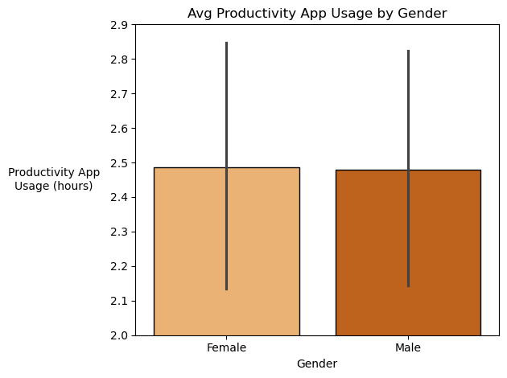

```python
orange_colors = ["#FDB462", "#D95F02"]
unique_genders = smartphone_filtered["Gender"].dropna().unique()
gender_palette = dict(zip(unique_genders, orange_colors))

fig, ax = plt.subplots()

sns.barplot(
    data=smartphone_filtered,
    x='Gender',
    y='Productivity_App_Usage_Hours',
    hue='Gender',
    palette=gender_palette,
    dodge=False,
    edgecolor="black",
    legend=False
)

ax.set_ylabel('Productivity App\nUsage (hours)', rotation=0, labelpad=50, va='center')
ax.set_ylim(2.0, 2.9)
ax.set_title('Avg Productivity App Usage by Gender')
plt.tight_layout()
plt.show()
```

This bar plot compares productivity app usage between females and males. This shows that average productivity app usage is very similar between these two genders but females use them slightly more.

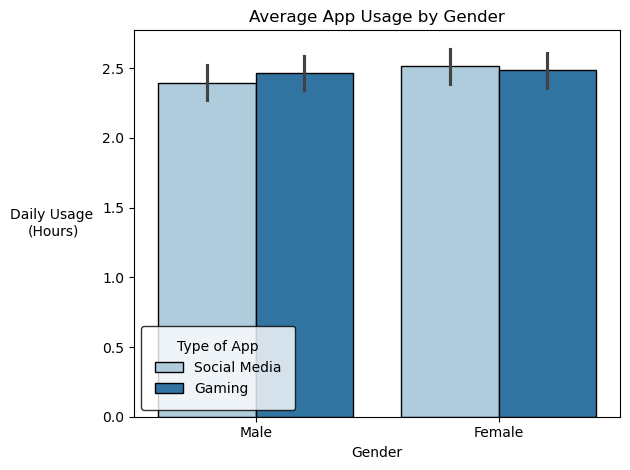

```python
spusage = smartphone_df.melt(
    id_vars=['Gender'],
    value_vars=['Social_Media_Usage_Hours', 'Gaming_App_Usage_Hours'],
    var_name='App_Type',
    value_name='Usage_Hours'
)

spusage['App_Type'] = spusage['App_Type'].replace({
    'Social_Media_Usage_Hours': 'Social Media',
    'Gaming_App_Usage_Hours': 'Gaming'
})
colors = ["#a6cee3", "#1f78b4"]
fig, ax = plt.subplots()
sns.barplot(data=spusage, x='Gender', y='Usage_Hours', hue='App_Type', palette=colors, edgecolor="black")
ax.set_ylabel('Daily \nUsage (hours)', rotation=0, labelpad=35, va='center')
ax.set_title('Average App Usage by Gender')
plt.ylabel('Daily Usage \n(Hours)')
ax.legend(
    title='Type of App',
    loc='lower left',
    bbox_to_anchor=(0, 0),
    frameon=True,
    borderpad=1,
    edgecolor='black'
)

plt.tight_layout()
plt.show()
```

```python
social_df = pd.read_csv("data/social.csv")
social_df['Age'] = pd.to_numeric(social_df['Age'], errors='coerce')
social_filtered = social_df[(social_df['Age'] >= 21) & (social_df['Age'] <= 25)].copy() ## setting age limits
social_filtered['Daily_Usage_Time (minutes)'] = social_filtered['Daily_Usage_Time (minutes)'] / 60 ## converting minutes to hours
social_filtered.rename(columns={'Daily_Usage_Time (minutes)': 'Daily_Usage_Time_Hours'}, inplace=True)
print(social_filtered.describe())
social_filtered.head(5)
```

```
              Age  Daily_Usage_Time_Hours  Posts_Per_Day  \
count  306.000000              306.000000     306.000000
mean    23.019608                1.589325       3.483660
std      1.423321                0.623544       1.864613
min     21.000000                0.666667       1.000000
25%     22.000000                1.166667       2.000000
50%     23.000000                1.333333       3.000000
75%     24.000000                2.000000       5.000000
max     25.000000                3.000000       8.000000

       Likes_Received_Per_Day  Comments_Received_Per_Day  \
count              306.000000                 306.000000
mean                40.627451                  15.248366
std                 26.093874                   7.874658
min                  5.000000                   2.000000
25%                 21.000000                   8.500000
50%                 33.000000                  14.000000
75%                 58.750000                  20.000000
max                100.000000                  38.000000

       Messages_Sent_Per_Day
count             306.000000
mean               21.888889
std                 7.723548
min                10.000000
25%                18.000000
50%                22.000000
75%                26.000000
max                45.000000
```

|  | User_ID | Age | Gender | Platform | Daily_Usage_Time_Hours | Posts_Per_Day | Likes_Received_Per_Day | Comments_Received_Per_Day | Messages_Sent_Per_Day | Dominant_Emotion |
| --- | --- | --- | --- | --- | --- | --- | --- | --- | --- | --- |
| 0 | 1 | 25.0 | Female | Instagram | 2.000000 | 3.0 | 45.0 | 10.0 | 12.0 | Happiness |
| 2 | 3 | 22.0 | Non-binary | Facebook | 1.000000 | 2.0 | 15.0 | 5.0 | 20.0 | Neutral |
| 5 | 6 | 21.0 | Male | Instagram | 2.500000 | 4.0 | 60.0 | 15.0 | 25.0 | Happiness |
| 7 | 8 | 24.0 | Non-binary | Facebook | 1.833333 | 6.0 | 25.0 | 12.0 | 22.0 | Sadness |
| 10 | 11 | 23.0 | Female | Twitter | 1.250000 | 4.0 | 35.0 | 7.0 | 20.0 | Anxiety |

```python
print(social_filtered.isnull().sum())
social_filtered.isnull().values.any()
social_filtered.isnull().sum().sum()
```

```
User_ID                      0
Age                          0
Gender                       0
Platform                     0
Daily_Usage_Time_Hours       0
Posts_Per_Day                0
Likes_Received_Per_Day       0
Comments_Received_Per_Day    0
Messages_Sent_Per_Day        0
Dominant_Emotion             0
dtype: int64
```

```
0
```

From the .describe() output, we observed that:

- The average daily usage was 1.59 hours, ranging from .67 to 3 hours, suggesting that most participants engage regularly but not excessively with social media.
- Posts per day averaged around 3.48, with a maximum of 8, implying moderate sharing activity across users.
- Users received on average 40.6 likes per day, with a standard deviation of 26, showing variation in popularity or follower engagement across individuals.
- Comments received had a mean around 15.2 and messages sent per day with a mean around 21.9, showing realistic and bounded distributions, with no outliers or implausible values, with maximum messages sent being 45.

Overall, the dataset is well-structured and exhibits healthy variance across behavioral indicators (e.g. posting, liking, messaging). These metrics allow us to explore how different levels of platform engagement relate to emotional states (e.g. via Dominant_Emotion). Because these values are realistic and balanced, the dataset is high quality and ready for analysis without further cleaning.

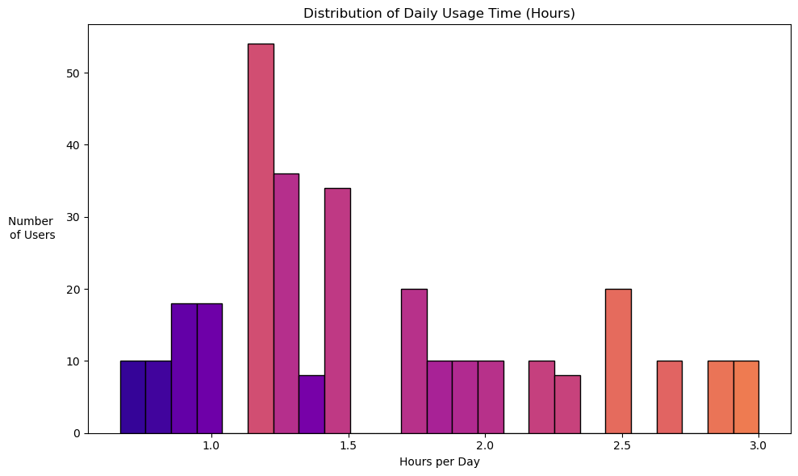

```python
data = social_filtered["Daily_Usage_Time_Hours"].dropna()
num_bins = 25
counts, bins = np.histogram(data, bins=num_bins)
bin_centers = 0.5 * (bins[:-1] + bins[1:])

# Normalize values for color blending
x_norm = Normalize(vmin=min(bin_centers), vmax=max(bin_centers))
y_norm = Normalize(vmin=min(counts), vmax=max(counts))

# Choose colormap
cmap = colormaps["plasma"]
blend_colors = [cmap(0.6 * x_norm(x) + 0.4 * y_norm(y)) for x, y in zip(bin_centers, counts)]

# Plotting
fig, ax = plt.subplots(figsize=(10, 6))
for i in range(len(bins) - 1):
    ax.bar(
        bins[i],
        counts[i],
        width=bins[i + 1] - bins[i],
        color=blend_colors[i],
        edgecolor="black",
        align="edge"
    )

# Axis labels and title
ax.set_ylabel('Number \nof Users', rotation=0, labelpad=30, va='center')
ax.set_xlabel("Hours per Day")
ax.set_title("Distribution of Daily Usage Time (Hours)")

plt.tight_layout()
plt.show()
```

This plot shows the distribution of social media usage time within our dataset. In this dataset, a good portion of the subjects' social media usage is within 1-2 hours a day. The color graident is used to show which users have higher daily averages and how some users have a particular daily usage time (blue = low daily average, amount of users; pink/orange = high daily usage and amount of users).

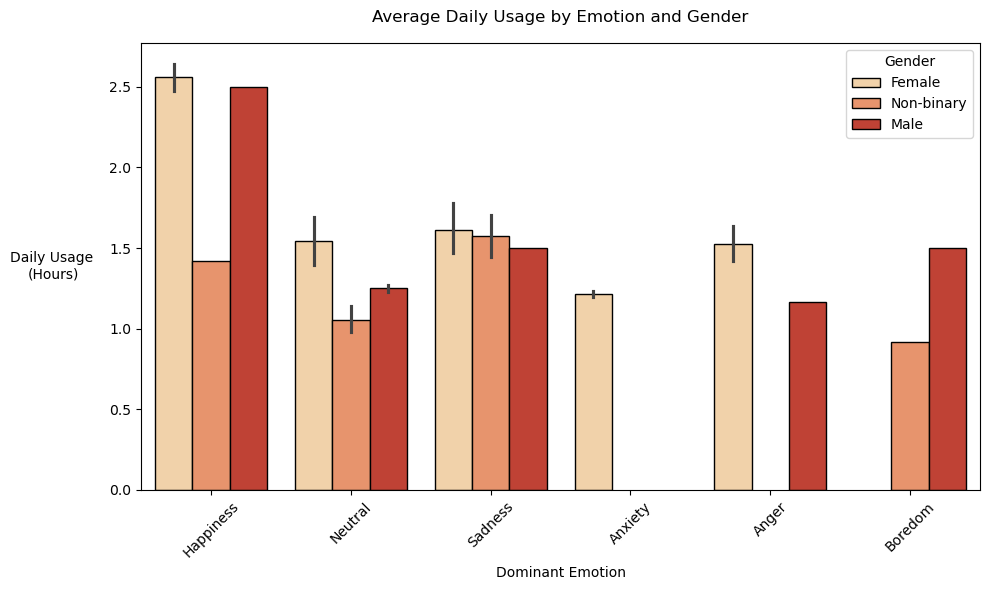

```python
unique_genders = social_filtered["Gender"].dropna().unique()
warm_palette = sns.color_palette("OrRd", n_colors=len(unique_genders))
emotion_color_map = dict(zip(unique_genders, warm_palette))

plt.figure(figsize=(10, 6))
sns.barplot(
    data=social_filtered,
    x='Dominant_Emotion',
    y='Daily_Usage_Time_Hours',
    hue='Gender',
    palette=emotion_color_map,
    estimator='mean',
    dodge=True,
    edgecolor="black"
)

plt.title('Average Daily Usage by Emotion and Gender', loc='center', pad=15)
plt.ylabel("Daily Usage \n(Hours)", rotation=0, labelpad=40, va='center')
plt.xlabel("Dominant Emotion")
plt.xticks(rotation=45)
plt.tight_layout()
plt.show()
```

# Results

## Exploratory Data Analysis

### Section 1 of EDA - Patterns in Productivity vs. Leisure App Usage

Goal: Explore how time is distributed among productivity, social media and gaming apps among 21-25 year olds using the Smartphone usage and Behavioral Dataset. We want to evaluate whether time spent on leisure apps (social media and gaming) is inversely related to productivity app use.

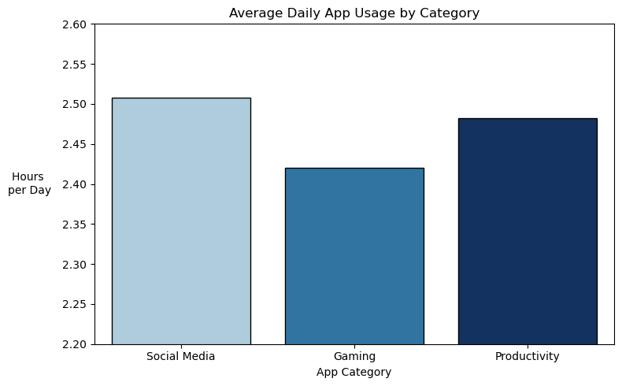

```python
avg_usage = {
    "Social Media": smartphone_filtered["Social_Media_Usage_Hours"].mean(),
    "Gaming": smartphone_filtered["Gaming_App_Usage_Hours"].mean(),
    "Productivity": smartphone_filtered["Productivity_App_Usage_Hours"].mean()
}

avg_df = pd.DataFrame({
    "Category": list(avg_usage.keys()),
    "Usage_Hours": list(avg_usage.values())
})

colors = ["#a6cee3", "#1f78b4", "#08306b"]

plt.figure(figsize=(8, 5))
sns.barplot(
    data=avg_df,
    x="Category",
    y="Usage_Hours",
    hue="Category",
    palette=colors,
    dodge=False,
    edgecolor="black",
    align="edge"
)

plt.ylim(2.2, 2.6)
plt.title("Average Daily App Usage by Category")
plt.ylabel("Hours \nper Day", rotation=0, labelpad=30, va='center')
plt.xlabel("App Category")
plt.tight_layout()
plt.show()
```

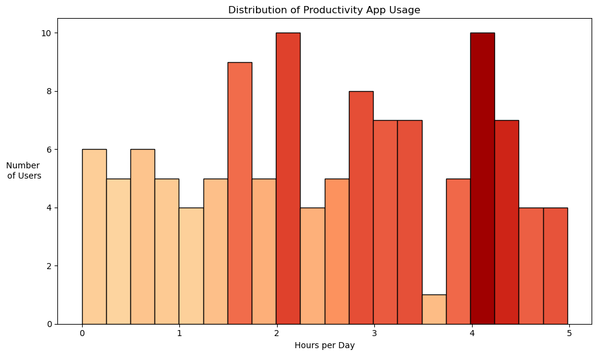

```python
data = smartphone_filtered["Productivity_App_Usage_Hours"].dropna()

n_bins = 20
counts, bins = np.histogram(data, bins=n_bins)
bin_centers = 0.5 * (bins[:-1] + bins[1:])

x_norm = Normalize(vmin=min(bin_centers), vmax=max(bin_centers))
y_norm = Normalize(vmin=min(counts), vmax=max(counts))

cmap = colormaps["OrRd"]
colors = [cmap(0.5 * x_norm(x) + 0.5 * y_norm(y)) for x, y in zip(bin_centers, counts)]

plt.figure(figsize=(10, 6))
for i in range(len(bins) - 1):
    plt.bar(
        bins[i],
        counts[i],
        width=bins[i + 1] - bins[i],
        color=colors[i],
        edgecolor="black",
        align="edge"
    )

plt.title("Distribution of Productivity App Usage")
plt.xlabel("Hours per Day")
plt.ylabel("Number \nof Users", rotation=0, labelpad=20, va='center')
plt.tight_layout()
plt.show()
```

This bar chart represents the distribution of productivity app usage, comparing the number of users (y-axis) and the amount of hours per day (x-axis). The tallest bars are at 2 and 4 hours per day, both having 10 users in that group. There are multiple bars past the 2 hour range that are warmly colored, indicating that a significant amount of proportion uses a moderate amount of time using productivity apps. There is a wide spread from 0 to 5 hours a day when it comes to productivity apps, suggesting there is a large amount of variance in the data in how much people use these apps. Overall, this chart shows there are notable spikes in users who use productivity apps 2 or 4 hours per day, with the rest of the hours on the graph being uniform.

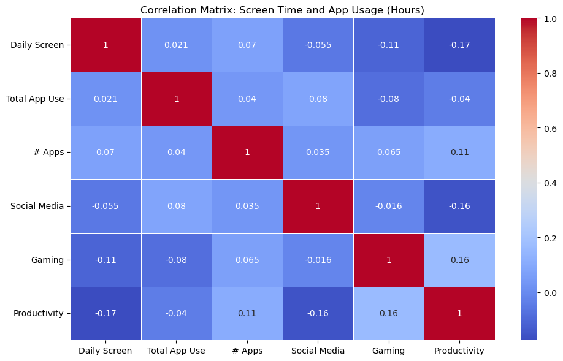

```python
corr_cols = [
    "Daily_Screen_Time_Hours",
    "Total_App_Usage_Hours",
    "Number_of_Apps_Used",
    "Social_Media_Usage_Hours",
    "Gaming_App_Usage_Hours",
    "Productivity_App_Usage_Hours"
]

label_map = {
    "Daily_Screen_Time_Hours": "Daily Screen",
    "Total_App_Usage_Hours": "Total App Use",
    "Number_of_Apps_Used": "# Apps",
    "Social_Media_Usage_Hours": "Social Media",
    "Gaming_App_Usage_Hours": "Gaming",
    "Productivity_App_Usage_Hours": "Productivity"
}

corr_matrix = smartphone_filtered[corr_cols].corr()
corr_matrix.rename(columns=label_map, index=label_map, inplace=True)

plt.figure(figsize=(10, 6))
sns.heatmap(corr_matrix, annot=True, cmap="coolwarm", linewidths=0.5)
plt.title("Correlation Matrix: Screen Time and App Usage (Hours)")
plt.xticks(rotation=0)  # Make x-axis labels horizontal
plt.xticks(rotation=0, ha='center', fontsize=10)
plt.tight_layout()
plt.show()
```

This heat map shows the correlation between screen time and app usage in hours, comparing the different categories of Daily Screen Time, Total App Usage, Number of Apps, Social Media Apps, Gaming Apps, and Productivity Apps.

- Most of the correlations are very close to 0, indicating there is a very weak or no linear relationship between variables.
- The negative correlations (Daily screen time and productivity: -0.17; Total App Use and Productivity: -0.04; and Social Media and Productivity: -0.16) suggests that a higher screen time and usage might be slightly associated with lower productivity.
- There is a positive correlation between productivity and Gaming, with 0.16, which could suggest that gaming does not hinder productivity.
- Having more apps is slightly positively correlated with productivity. This could imply that people with a wider range of apps have more productivity tools.

Overall, this heatmap indicated weak correlations between screen/ app usage and productivity, while there is a small trend that could suggest that more screen time is linked to lower productivity, none of the relationships are strong enough to make a firm conclusion.

#### Section 1 Findings

The Distribution of Productivity App Usage histogram shows us the variance of the amount of hours spent on productivity apps. We chose to include this visualization to show whether there is a trend within our dataset’s usage of productivity apps. There is a roughly even distribution throughout 0-5 hours except for a peak around 2 and 4 hours of usage. Although there are peaks, the data is still very uniform, indicating that people’s productivity app usage within our dataset is highly varied. With data that is this consistent, it will be harder to make predictions based on our hypothesis and compare to leisure app usage.

Lastly, the Correlation Matrix: Screen Time App Usage (Hours) compares the correlation between time spent within the different categories we tested, such as productivity, gaming, social media, etc. The graph is for the most part blue (low correlation) and most values are very close to zero. This indicates that within our dataset, there is little to no relationship between productivity app usage & social media/gaming app usage and that they do not have a significant effect on each other. Overall, we cannot conclude that there is an inverse relationship nor any significant correlation between productivity and leisure app usage.

### Section 2 of EDA: Social Media Engagement and Emotional Well-Being

Goal: Explore how emotional states (e.g., happy, sad, angry) vary across platforms and whether higher social media engagement (e.g., posts, likes) is associated with more negative or positive emotional states.

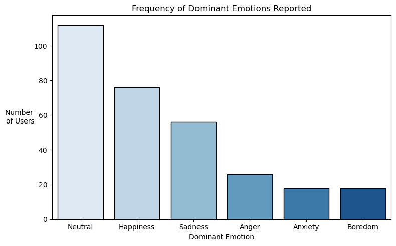

```python
emotion_order = social_filtered["Dominant_Emotion"].value_counts().index.tolist()
blue_palette = sns.color_palette("Blues", len(emotion_order))
emotion_color_map = dict(zip(emotion_order, blue_palette))

plt.figure(figsize=(8, 5))
sns.countplot(
    data=social_filtered,
    x="Dominant_Emotion",
    hue="Dominant_Emotion",
    order=emotion_order,
    palette=emotion_color_map,
    legend=False,
    edgecolor="black",
    align="edge"
)

plt.title("Frequency of Dominant Emotions Reported")
plt.xlabel("Dominant Emotion")
plt.ylabel("Number \nof Users", rotation=0, labelpad=20, va='center')  # Horizontal and centered y-axis label
plt.xticks(rotation=0)
plt.tight_layout()
plt.show()
```

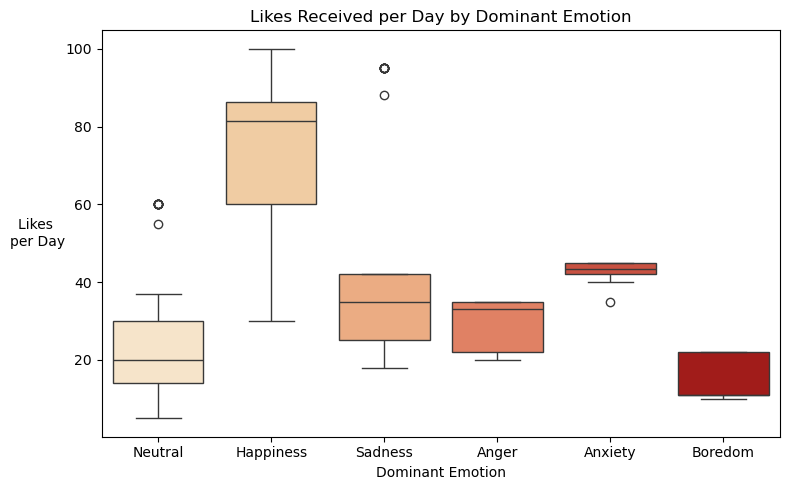

```python
emotion_order = social_filtered["Dominant_Emotion"].value_counts().index.tolist()
warm_palette = sns.color_palette("OrRd", len(emotion_order))
emotion_color_map = dict(zip(emotion_order, warm_palette))

plt.figure(figsize=(8, 5))
sns.boxplot(
    data=social_filtered,
    x="Dominant_Emotion",
    y="Likes_Received_Per_Day",
    hue="Dominant_Emotion",
    palette=emotion_color_map,
    order=emotion_order,
    dodge=False,
    legend=False
)

plt.title("Likes Received per Day by Dominant Emotion")
plt.xlabel("Dominant Emotion")
plt.ylabel("Likes \nper Day", rotation=0, labelpad=20, va='center')  # Horizontal y-axis label
plt.xticks(rotation=0)
plt.tight_layout()
plt.show()
```

This boxplot depicts the five number summary of likes received per day sorted by dominant emotion.

- ‘Happiness’ has a significantly larger range than the other emotions, and its IQR (median sitting at ~80) corresponds to a greater number of likes than any other emotion.
- Instances of the other dominant emotions, including ‘Neutral’, all waver around the 10-50 range for likes per day.
- ‘Neutral’ has two outliers at around 60 likes per day, and ‘Sadness’ has two outliers in the 80-100 range for likes per day.

This plot demonstrates the potential relationships between likes per day and dominant emotion, suggesting that ‘Happiness’ corresponds to greater number of likes, while the others relate to lower amounts.

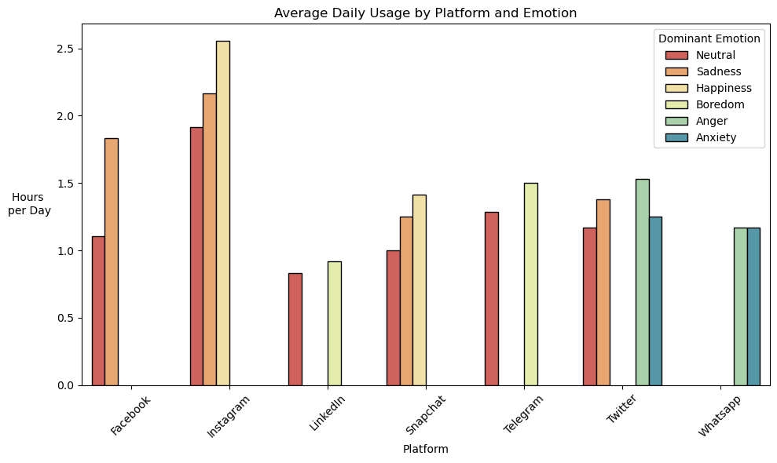

```python
platform_emotion_means = social_filtered.groupby(["Platform", "Dominant_Emotion"])["Daily_Usage_Time_Hours"].mean().reset_index()

plt.figure(figsize=(10, 6))
sns.barplot(
    data=platform_emotion_means,
    x="Platform",
    y="Daily_Usage_Time_Hours",
    hue="Dominant_Emotion",
    palette="Spectral",
    edgecolor="black"
)

plt.title("Average Daily Usage by Platform and Emotion")
plt.ylabel("Hours \nper Day", rotation=0, labelpad=25, va='center')
plt.xlabel("Platform")
plt.xticks(rotation=45)

plt.legend(
    title="Dominant Emotion",
    loc='upper right',
    bbox_to_anchor=(1, 1),
    frameon=True
)

plt.tight_layout()
plt.show()
```

#### Section 2 Findings

From the social media dataset, we created several visualizations that would help us reach our goal of analyzing the relationship between an individual’s social media activity and their emotions. First, we observed the distribution of each dominant emotion reported across all platforms in Frequency of Dominant Emotions Reported. From this graph, we determined that the most common dominant emotion was ‘Neutral’, followed by ‘Happiness’, and finally, the negative emotions (e.g. ‘Sadness’, ‘Anger’). With this distribution as a starting point, we continued to explore our given features sorted by dominant emotion.

In Likes Received Per Day by Dominant Emotion, we chose to represent the intensity of a user’s online engagement with the average number of likes they received per day. The boxplot shows that for users of all social media platforms, ‘Happiness’ is the only dominant emotion that corresponds to higher average likes per day with a median of around 80 likes per day. In contrast, ‘Neutral’ and the negative emotions correlate with significantly lower numbers of likes per day, with medians ranging from 20 to 40 daily likes. This suggests that a greater amount of online engagement correlates with positive emotions such as happiness over negative ones.

Finally, in Average Daily Usage by Platform and Emotion, we organized daily hours spent on social media by the app used and the dominant emotion experienced. From this grouped bar chart, we made several observations regarding the spread of dominant emotions across different platforms. We noticed that although ‘Neutral’ is recorded as a dominant emotion for all platforms other than Whatsapp, it never ranks the highest in relation to daily hours spent. This suggests that more social media usage has correlations to changes in emotion away from neutrality. Each platform has a different recorded dominant emotion (such as “Happiness” for Instagram or “Anger” for Twitter) which could be explained by the various forms of content and user communities based on each platform.

# Ethics & Privacy

Screen time data can be highly personal, potentially revealing sensitive details about user behavior, app preferences, and daily routines. To protect user privacy, we will only use anonymized and publicly available datasets that have been ethically sourced and shared with consent. We will avoid using any data obtained from platforms or applications without explicit user permission or proper anonymization. Additionally, we will ensure that none of our analysis could indirectly re-identify individuals, especially if we cross reference multiple data sources.

Our focus is on individuals aged 21-25 in the United States, but we recognize that existing datasets may not fully represent this group across all socioeconomic, racial, geographic, or educational lines. Self-reported screen time data may also introduce recall bias, while datasets collected from certain platforms (eg. app-based trackers) may disproportionately reflect certain demographics (eg. tech savvy or higher income users).

To detect biases before during and after:

- We will prioritize datasets that include objective measures of screen time (eg. device-tracked logs rather than self-reports)
- We will stratify our analysis by demographics such as age, gender, income, education level, and geographic region where available
- We will report any gaps or skews in the data and avoid overgeneralizing results beyond the represented population
- We will compare multiple datasets if possible to check for consistency and reduce reliance on a single biased source.

There is a risk that our findings could be overinterpreted to stigmatize high smartphone use or productivity patterns among certain groups. For instance, lower productivity app usage may not necessarily indicate poor time management, instead it could reflect socioeconomic differences in job types, access to resources, or cultural habits. There is also the possibility that our analysis could unintentionally promote overgeneralized conclusions about smartphone use and attention without considering context.

To address these concerns:

- We will clearly qualify our claims based on the limitations of our data
- We will emphasize that correlation does not imply causation and note other potential factors influencing app usage behavior
- We will contextualize our conclusions to prevent harmful or misleading narratives about specific user groups.

# Discusison and Conclusion

This study suggests that while high engagement with social media and gaming apps may not directly reduce productivity app use, it does have a role in affecting the emotional states of its users. From the section Patterns in Productivity vs. Leisure App Usage, we did not find any inverse relationship nor any significant correlation between productivity and leisure app usage. Meanwhile, in Social Media Engagement and Emotional Well-Being, user behaviors like receiving more likes corresponded to ‘Happiness’ dominating. We also found in this section that different social media platforms had different dominant emotions (such as “Happiness” for Instagram or “Anger” for Twitter) which suggests that users of different platforms will experience different emotions based on the platform they choose to interact with.

For the second part of our hypothesis, we did find that social media engagement had implications on emotional well-being. This was illustrated by how the users who received more likes had ‘Happiness’ as their dominant emotion, while the other emotions (neutral, sadness, anxiety, and boredom) all correlated to lower like counts. This implies that engagement on social media may not solely rely on the amount of time spent on the platform, but from the quality of the activity. Additionally, no social media platform had an overall dominant emotion of ‘Neutral’, suggesting that spending time on platforms amplifies emotions.

There are some limitations to this research. Our two datasets represent two different sets of user populations that are not inherently related to each other. Additionally, emotional description can be more complex than the labels provided in the second dataset. Further research can be made addressing these limitations by using a broader dataset that collects additional information.

# Team Contributions

- Rylee - Background, Abstract, Data Analysis/Description, Video
- Liz - Data Cleaning/Wrangling, EDA Code, Research, Data Analysis/Description, Ethics
- Winston - Data Cleaning/Wrangling, Initial Data Visualization, Analysis/Description
- Jocelyn - Data Analysis/Description, Team Expectation, Timeline
- Jayleen - Data Analysis/Description, Proposal Ideas, Findings writeup